[figure not shown]

# Алгоритмы интеллектуальной обработки больших объемов данных

## Деревья решений, случайные леса

## Quiz Time!

# Деревья решений

## Пример 1

- Некоторая кoмпания открыла курс по разработке приложений на Andriod для (всех) студентов МГУ
- Прошло уже несколько наборов
- По результатам каждого отбора слушатели отставляют отзыв (`+1`|`-1`)
- О слушателях известно
  - Пол
  - Возраст
  - Курс
  - Факультет
  - Посещаемость
  - Оценки за ДЗ
  - ...

Компания просит у исследователя описать те группы слушателей, которым курс не понравился, чтобы возможно как-то его улучшить.

В идеальном мире исследователь должен прийти с чем-то вроде

- `[Пол = Ж][Возраст > 21][Факультет = Экономика][Посещаемость < 50%]` - не нравится в 82% случаев
- `[Пол = М][Возраст >= 20][Факультет = ВМК][Средний балл > 4.5]` - не нравится в 10% случаев
- ...

## Пример 2

- Вы приходите в банк за кредитом не дай бог, подаете анкету со всеми необходимыми документами
- Сотрудник банка проверяет вашу анкету:
  1. Если объем сбережений <= 200 тыс., то перейти к шагу 2, иначе - к шагу 3.
  2. Если стаж больше года - дать кредит, иначе - не давать
  3. Если продолжительность займа < 30 месяцев - не давать кредит, иначе - к шагу 4
  4. ...

[figure not shown]

Формально, дерево решений - это связный ациклический граф. В нем можно выделить 3 типа вершин:

1. Корневая вершина (root node) - откуда все начинается
2. Внутренние вершины (intermediate nodes)
3. Листья (leafs) - самые глубокие вершины дерева, в которых содержится "ответ"

Во внутренней или коневой вершине признак проверяется на некий логический критерий, по результатам которого мы движемся все глубже

## Обобщенный псевдокод алгоритма построения дерева

```
{python}
1. function decision_tree(X, y):

2.    if stopping_criterion(X, y) == True:

3.        S = create_leaf_with_prediction(y)

4.    else:

5.        S = create_node()
6.        (X_1, y_1) .. (X_L, y_L) = best_split(X, y)

7.        for i in 1..L:
8.            C = decision_tree(X_i, y_i)
9.            connect_nodes(S, C)
10.   return S
```

## Как определяются лучшие разбиения (best splits)?

### Меры неопределенности (impurity measures)

По какому мешку лучше классифицировать?

[figure not shown]

## Как определяются лучшие разбиения (best splits)?

### Меры неопределенности (impurity measures)

Пусть $p_k$ - это доля класса $C_k$ в узле дерева $S$.

1. Missclassification error
   $$I(S) = 1 - \max\limits_k p_k $$
2. Gini index $$I(S) = 1 - \sum\limits_k (p_k)^2 = \sum\limits_{k'\neq k} p_{k'} p_k$$
3. Entropy $$I(S) = -\sum\limits_k p_k \log(p_k)$$

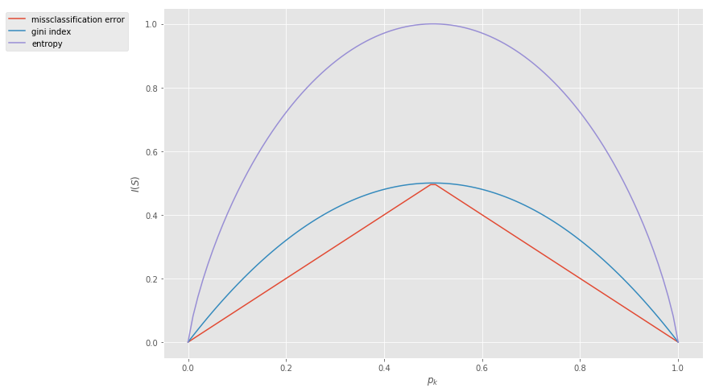

```python
plot_impurities()
```

## Как определяются лучшие разбиения (best splits)?

### Прирост информации

Выберем признак $A$ и пороговое значение $t$ на нем таким образом, чтобы уменьшить неопределенность:

**Насколько уменьшится неопределенность:**
$$ Gain(S, A) = I(S) - \left(\frac{|S_L|}{|S|}\cdot I(S_L) + \frac{|S_R|}{|S|}\cdot I(S_R) \right),$$ где $S_R$ и $S_L$ - это потомки узла $S$ c объектами, удовлетворяющим соответствующим условиям.

- Стратегия выбора - жадная
- Как определяется порог при вещественных признаках?
- Что если категорий у признака много? [Breiman, et al](https://www.amazon.co.uk/Classification-Regression-Wadsworth-Statistics-Probability/dp/0412048418)
- Локальная оптимизация - уменьшение Impurity внутри узла
- Результаты не сильно зависят от выбора самой меры неопределенности

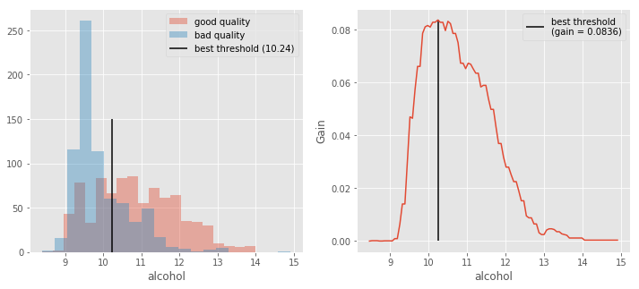

```python
def impurity(p):
    # p - массив из долей каждого из классов
    # Имплементируйте любую меру неопределенности
    return 1 - (p**2).sum()
#     return 1 - np.max(p)
#     return -np.sum(p*np.log2(p))
wine_demo()
```

## Классификация

```python
try:
    fig = interact(demo_dec_tree, depth=IntSlider(min=1, max=5, value=1))
except:
    print('Что-то не так. Посмотрите на доску')
```

## Критерии останова (регуляризация)

- Никогда
- Задать порог по мере неопределенности: $I(S) \leq \theta$
- Задать порог по размеру узла: $|S| \leq n$
- Задать порог на глубину: $Depth(S) = d$
- Задать порог на размер потомков: $|S_L| \leq n_1 \& |S_R| \leq n_2$
- ...

## Регрессия

Для задачи регрессии в качестве меры неопределенности могут выступать

- Среднее квадратичное отклонение от среднего $$ I(S) = \frac{1}{|S|}\sum\limits_{i \in S}(y_i - \bar{y_S})^2 $$
- Среднее абсолютное отклонение от медианы $$ I(S) = \frac{1}{|S|}\sum\limits_{i \in S}|y_i - \bar{y_S}| $$

```python
try:
    fig = interact(plot_dec_reg, depth=IntSlider(min=1, max=5, value=1), criterion=['mse', 'mae'])
except:
    print('Что-то не так. Посмотрите на доску')
```

## Как определяется ответ?

- Классификация
  - Класс с большинством в листе
  - Доли каждого из классов в листе
- Регрессия
  - Среднее (медиана) целевой переменной в листе

## Важность признаков

В деревьях решений производится автоматический отбор признаков.

Пусть $v(S)$ - это признак, который использовался для ветвления в узле $S$

$$ \text{imp}(A) = \sum\limits_{i: v(S_i) = A} \frac{|S_i|}{|S|} Gain(S_i, A) $$

## Работа с пропусками

1. Удалить объекты\признаки с пропусками
2. Пропущенное значение = отдельная категория
3. Вычисление impurity без учета пропуска
4. Surrogate split

## Вычислительная сложность

#### Обучение

- Расчет мер неопределенности для $n$ объектов с $d$ признаками на одном уровне:
  - $O(dn)$
- Надо делать на каждом уровне дерева. Глубина дерева в сбалансированном случае случае - $\log{(n)}$
  - $O(dn \log{(n)})$

#### Применение

- В худшем случае $O(n)$
- В сбалансированном случае $O(\log{(n)})$

## Специальные алгоритмы построения деревьев

**ID 3**

- Только категориальные признаки
- Количество потомков = количеству значений признака
- Строится до максимальной глубины

**С 4.5**

- Поддержка вещественных признаков
- Категриальные как в ID3
- При пропуске значения переход по всем потомкам
- Удаляет избыточные ветвления

**СART**

- В основном сегодняшнее занятие про него
- Специальная процедура усещения дерева после построения (post prunning)

## Преимущества / Недостатки

**Преимущества**

- Простота построения
- Интерпретируемость (при небольшой глубине)
- Требуются минимальная предобработка признаков
- Встроенный отбор признаков

**Недостатки**

- Границы строяется только параллельно или перпендикулярно осям признаков
- При изменении набора данных надо полностью перестраивать и результат может получится совершенно иным
- Жадность построения

# Случайный лес (Random Forest)

Дерево решений очень чувствительно к данным

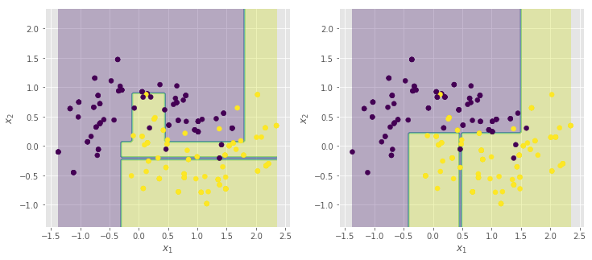

```python
demo_2dec_tree()
```

Bagging - это параллельный способ построения ансамбля.

1. Обучающая выборка сэмплируется $k$ раз с помощью *bootstrap'a* (выборка с возвратом)
2. На каждом сэмпле обучается отдельная **базовая модель**
3. Ответы моделей усредняются (возможно с весом)

[figure not shown]

*Вопрос: Какая доля объектов в среднем попадает в один bootstrap сэмпл?*

## Почему усреднение работает?

- Какая высота у Эйфелевой башни?
- Кто здесь леопард?

Так же есть некоторые обобщения бэггинга:

- Метод случайных подпространств - на шаге 1. сэмплируются не только объекты, но и подпространство признаков
- Метод случайного леса - на каждом узле сэмплируется подпространство признаков

В данном случае, на каждом сэмпле базовой моделью является дерево решений.  
Если вам нужно за минимальное время построить достаточно точную и устойчивую модель - это ваш вариант.

```python
try:
    fig = interact(rf_demo, n_est=IntSlider(min=1, max=101, value=1, step=5))
except:
    print('Что-то не так. Посмотрите на доску')
```

## Полезные ссылки

- [Как работают деревья "на пальцах"](http://www.r2d3.us/visual-intro-to-machine-learning-part-1/)
- [Про визуализацию деревьев решений](http://explained.ai/decision-tree-viz/index.html)
- [Гайд про энтропию](http://clear-lines.com/blog/post/Discretizing-a-continuous-variable-using-Entropy.aspx)
- [Гайд про энтропию 2](http://kevinmeurer.com/a-simple-guide-to-entropy-based-discretization/)

# Доп. Материалы

- Mohammed J. Zaki. Data Mining and Analysis: Fundamental Concepts and Algorithms. Ch19
- Trevor Hastie, et al. The Elements of Statistical Learning. Ch9.2
- [Random Forests Home](https://www.stat.berkeley.edu/~breiman/RandomForests/cc_home.htm)

## Вопросы?

## Пожалуйста, оставьте отзыв о лекции